# Feature Selection & Extraction

### J.A.

You have seen in the previous lab that visualizing datasets in 2 or 3 dimensions is quite convenient. But when the number of features is in the order of tens, hundreds, or thousands, feature reduction becomes an essential tool. Visualization is one motivation for feature reduction. Another reason for reducing dimensionality is to improve statistical estimates such as when estimating the covariance matrix of a dataset. Sometimes a large amount of data is required to estimate even simple parameters in 3 dimensional spaces. With higher dimensions, the number of samples required grows exponentially, wherefore it would be far easier to remove dimensions rather than add samples, especially that this latter may not be possible. Feature reduction is crucial for a large portion of classification tasks as well as regression problems. In this lab, we explore two general approaches to dimensionality reduction: *feature selection* and *feature extraction*.

## Feature Selection

In feature selection, we simply select a subset of features from the available ones and drop the others. In order to do this, we require a criterion function to assess a given feature subset and a method to choose subsets, that is, we require a search algorithm. A number of search algorithms were presented, namely 'the best individual *d* features', forward selection, backward selection, plus-l-take-away-r selection, and branch & bound. Scikit-learn provides **RFE()** that performs backward feature selection.

**Exercise 1**. Explore **RFE()** by reading the help menu; note that the module to be imported is **sklearn.feature_selection**. You may choose the desired number of features through the parameter 'n_features_to_select'. We will use the support vector classifier to obtain classification rates of feature subsets as our criterion. Run the code below, but make sure you understand every line. What does the dataset $X$ consist of? Which are the four features that were selected? Are those the ones you had expected?

```python
import numpy as np
import pandas as pd
from sklearn import datasets
from sklearn.feature_selection import RFE
from sklearn.svm import SVC

iris = datasets.load_iris()
meas = iris.data
y = iris.target
X = np.random.multivariate_normal(mean=[0]*10, cov=np.diag([1]*10), size=150)
X = pd.DataFrame(X, columns=[f'V{i}' for i in range(10)])

X[['V0','V2','V4','V6']] = meas #or X.iloc[:,[0,2,4,6]]

svc = SVC(kernel="linear", C=1)
rfe = RFE(estimator=svc, n_features_to_select=4, step=1)
rfe.fit(X, y)
rfe.support_.nonzero()
```

```
(array([0, 2, 4, 6]),)
```

## Principal Component Analysis

Principal component analysis is a feature extraction method that is very useful. It is a linear, unsupervised feature extraction method. PCA is often applied when working with signals such as sound, speech, images, etc.

**Exercise 2**. Read in the data file 'sonar.txt'. The dataset consists of echo signals with 60 features. Apply PCA to the data using **PCA()** from module **sklearn.decomposition**, and plot the ratio of retained variance to total variance (hint: **cumsum()**). The ratio of retained variance to total variance should be in the range $[0,1]$. What can you deduce from the plot? Use the method **fit_transform()** to obtain object coordinates in the transformed feature space.

**Exercise 3**. Repeat the previous exercise, however this time normalize your data properly prior to applying PCA as shown below. Describe how the data has been normalized by this manner? Now apply PCA as before, and plot the ratio of retained variance along with the previous result within the same figure (use different colors and a legend). Do the two plots coincide? Does your conclusion from the previous exercise still hold? How many features would you now choose to retain?

```python
from sklearn.preprocessing import StandardScaler
#data_scaled = StandardScaler().fit_transform(data)
```

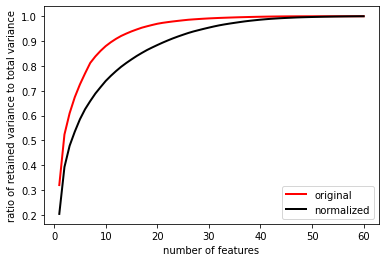

## Fisher Mapping

The Fisher mapping is a form of supervised, linear feature extraction. Scikit-learn provides an implementation of the Fisher mapping through **LinearDiscriminantAnalysis()**.

**Exercise 4**. Explore **LinearDiscriminantAnalysis()**. Load the iris dataset with four features, and apply the fisher mapping to obtain two features.

```python
from sklearn import datasets
from sklearn.discriminant_analysis import LinearDiscriminantAnalysis as LDA

iris = datasets.load_iris()
X = iris.data
y = iris.target

lda = LDA()
X_new = lda.fit_transform(X,y)
lda.fit(X,y).scalings_; #these are the coefficients
```

Derive the mapped data points in the new feature space, and plot the objects in the resulting two-dimensional (mapped) feature space while assigning each class a different color.

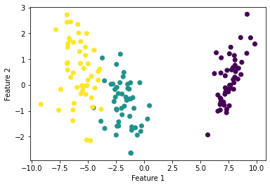

## Nonlinear Feature Extraction & Embedding

In this section, we will investigate nonlinear multi-dimensional scaling as a feature extraction method.

### Multi-dimensional Scaling

In the following exercise, we explore the effect of nonlinear multi-dimensional scaling visually in comparison to PCA, which is a linear mapping.

**Exercise 5**. Read in the file 'circles.txt' which contains 3 features. Generate a 3D scatter plot. Apply PCA using the whole dataset, and create a 2D scatter plot using the first two principal components with equal axes marks. How do the clusters appear? Can you tell them apart?

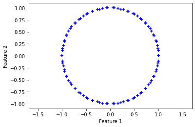

**Exercise 6**. Using the same dataset as in the previous exercise, you will now apply multi-dimensional scaling. Scikit-learn provides the method **MDS()** (module: **sklearn.manifold**) for multidimensional scaling (use 'n_components=2' as the desired number of dimensions). Create a 2D scatter plot of the result (use **fit_transform()** to obtain the embedded coordinates). Can you visualize the clusters now? How do the circles appear?

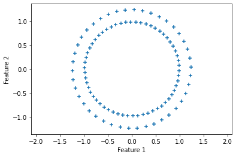

**Exercise 7**. Read in the data file 'lines.txt' which contains 5 features. Create a 3D scatter plot using the first 3 features. Then apply PCA on the entire 5D-dataset, and create a 2D scatter plot for the first two principal components.

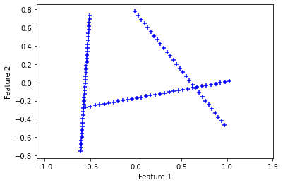

**Exercise 8**. Repeat the previous exercise using multidimensional scaling. How do the lines appear?

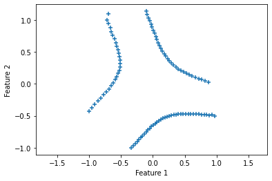

Multi-dimensional scaling can help highlight structure in the data that otherwise linear mappings may not be able to show. The price however is that the structure may appear distorted, and you should always keep that in mind when using nonlinear mapping techniques. It is dangerous to draw more conclusions than necessary or to see structure in the data that is not really there.

## Genetic Algorithms

This section will introduce you to genetic algorithms which you will apply on a known error function.

**Exercise 9**. Suppose you are given an error function, and you want to find the global minimum. Let that function be Rastrigin's function defined as:

$$e(x_1,x_2) = 20 + x_1^2 + x_2^2 - 10 (cos(2\pi x_1) + cos(2 \pi x_2)), \hspace{1em} x_1,x_2 \in R$$

It is known that the global minimum lies at $(x_1, x_2) = (0,0)$. However, we will assume we do not know this and will try to look for the global minimum.

Create a function **Rastrigin(x)** which returns the error as defined above. The parameter **x** is either a list or array whose first element is $x_1$ and second element $x_2$. Then plot the error function for $x_1, x_2 \in [-3,3]$ (eg using **np.linspace(-3,3,100)**)

Finally plot the error values using **plot_surface()**; also show a heatmap of the error values.

```python
def Rastrigin(x):
    err = 20 + x[0]**2 + x[1]**2 - 10*(np.cos(2*np.pi*x[0]) + np.cos(2*np.pi*x[1]))
    return err

x1 = np.linspace(-3,3,100)
x2 = np.linspace(-3,3,100)

e = np.array([Rastrigin([i,j]) for i in x1 for j in x2]).reshape(len(x1),len(x2))
e = pd.DataFrame(e, index=x1, columns=x2)

#...
```

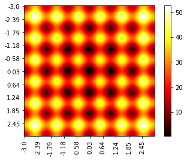

**Exercise 10**. The error function contains local mimina all around the global minimum at (0,0). This makes it impossible for gradient descent algorithms to converge to the global minimum unless the initial starting point happens to fall very close to the global minimum which is an unrealistic assumption. Instead, we will use a genetic algorithm in an attempt to find the global minimum efficiently. Use **geneticalgorithm()** from the source shown below: the first argument is a call to the error function; also specify the variable boundaries which in this case are $[-3,3]$. You may also set the number of individuals in the population using `population_size`, the ratio of elite individuals passing through to the next generation without any change using `elit_ratio`, and the fraction of offspring that is generated by crossover using `crossover_probability`.

```
 The best solution found:
 [-0.00020721  0.00015693]

 Objective function:
 1.3403678760681714e-05
```

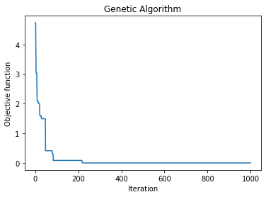

```python
#import sys
#!{sys.executable} -m pip install geneticalgorithm
#or:
#%pip install geneticalgorithm

from geneticalgorithm import geneticalgorithm as ga  #https://pypi.org/project/geneticalgorithm/

varbound = np.array([[-3,3]]*2)
algorithm_param = {'max_num_iteration':1000,
                   'population_size':20,
                   'mutation_probability':0.2,
                   'elit_ratio':2/100,
                   'crossover_probability':0.8,
                   'parents_portion': 0.3,
                   'crossover_type':'uniform',
                   'max_iteration_without_improv':None}

model = ga(function=Rastrigin, dimension=2, variable_type='real',
           variable_boundaries=varbound, algorithm_parameters=algorithm_param)
model.run()
```

Run the algorithm a few times and record the solution at each run. Does the algorithm converge to the correct global minimum? Does it always? How many iterations does it require?

**Exercise 11**. Repeat the previous exercise but with the number of elites set to zero and the crossover probability to 0.1. Do you think setting these options is wise? Does the algorithm often converge to the correct solution? Why is the algorithm now slower in converging?

**Exercise 12**. In general, when would you recommend using genetic algorithms over a classical gradient search optimization algorithm? Explain briefly.